# Top-level windows management

Compose Multiplatform for desktop provides various features for managing windows. You can hide windows in the tray, make them draggable, adapt their size, change position, and so on.

See also the new experimental window and dialog API v2.

## Open and close windows

You can use the `Window()` function to create a regular window. To put it in a composable scope, use `Window()` in the `application` entry point:

import androidx.compose.ui.window.Window import androidx.compose.ui.window.application fun main() = application { Window(onCloseRequest = ::exitApplication) { // Content of the window } }

As a composable function, `Window()` allows you to change its properties declaratively. For example, you can open a window with one title and change the title later:

import androidx.compose.material.Button import androidx.compose.material.Text import androidx.compose.runtime.getValue import androidx.compose.runtime.mutableStateOf import androidx.compose.runtime.remember import androidx.compose.runtime.setValue import androidx.compose.ui.window.Window import androidx.compose.ui.window.application fun main() = application { var fileName by remember { mutableStateOf("Untitled") } Window(onCloseRequest = ::exitApplication, title = "$fileName - Editor") { Button(onClick = { fileName = "note.txt" }) { Text("Save") } } }

[figure not shown]

### Add conditions

You can also open and close windows using simple `if` conditions. In the following code sample, the application window is automatically closed after completing a task:

import androidx.compose.material.Text import androidx.compose.runtime.LaunchedEffect import androidx.compose.runtime.getValue import androidx.compose.runtime.mutableStateOf import androidx.compose.runtime.remember import androidx.compose.runtime.setValue import androidx.compose.ui.window.Window import androidx.compose.ui.window.application import kotlinx.coroutines.delay fun main() = application { var isPerformingTask by remember { mutableStateOf(true) } LaunchedEffect(Unit) { // Do some heavy lifting delay(2000) isPerformingTask = false } if (isPerformingTask) { Window( onCloseRequest = ::exitApplication, title = "Window 1" ) { Text("Performing some tasks. Please wait!") } } else { Window( onCloseRequest = ::exitApplication, title = "Window 2" ) { Text("Hello, World!") } } }

[figure not shown]

### Ask for confirmation on close

If you want to use custom logic on application exit, such as showing a dialog, you can override the close action using the `onCloseRequest` callback. In the following code sample, instead of an imperative approach (`window.close()`), we use a declarative approach and close the window in response to the state change (`isOpen = false`).

import androidx.compose.material.Button import androidx.compose.material.Text import androidx.compose.runtime.getValue import androidx.compose.runtime.mutableStateOf import androidx.compose.runtime.remember import androidx.compose.runtime.setValue import androidx.compose.ui.window.DialogWindow import androidx.compose.ui.window.Window import androidx.compose.ui.window.application fun main() = application { var isOpen by remember { mutableStateOf(true) } var isAskingToClose by remember { mutableStateOf(false) } if (isOpen) { Window( onCloseRequest = { isAskingToClose = true }, title = "Important document" ) { if (isAskingToClose) { DialogWindow( onCloseRequest = { isAskingToClose = false }, title = "Close without saving?" ) { Button( onClick = { isOpen = false } ) { Text("Yes") } } } } } }

[figure not shown]

## Create a single-window application

For a simple application with one top-level window, you don't need the full `application` entry point with a `Window()` composable – the `singleWindowApplication()` function wraps both into a single call:

```
import androidx.compose.ui.window.singleWindowApplication

fun main() = singleWindowApplication {
    // Content of the window
}
```

For more than one top-level window, custom closing logic, or changing window attributes at runtime, use the `Window()` composable in the `application` entry point.

## Manage window state

The `WindowState` class holds window placement, current position, and size. The placement attribute allows you to specify how the window is placed on the screen: floating, maximized/minimized, or fullscreen. Any change of the state triggers automatic recomposition. To change the window state, use callbacks or observe it in composables:

import androidx.compose.foundation.clickable import androidx.compose.foundation.layout.Column import androidx.compose.foundation.layout.Row import androidx.compose.material.Checkbox import androidx.compose.material.Text import androidx.compose.ui.Alignment import androidx.compose.ui.Modifier import androidx.compose.ui.unit.dp import androidx.compose.ui.window.Window import androidx.compose.ui.window.WindowPlacement import androidx.compose.ui.window.WindowPosition import androidx.compose.ui.window.application import androidx.compose.ui.window.rememberWindowState fun main() = application { val state = rememberWindowState(placement = WindowPlacement.Maximized) Window(onCloseRequest = ::exitApplication, state, title = "Window state") { Column { Row(verticalAlignment = Alignment.CenterVertically) { Checkbox( state.placement == WindowPlacement.Fullscreen, { state.placement = if (it) { WindowPlacement.Fullscreen } else { WindowPlacement.Floating } } ) Text("isFullscreen") } Row(verticalAlignment = Alignment.CenterVertically) { Checkbox( state.placement == WindowPlacement.Maximized, { state.placement = if (it) { WindowPlacement.Maximized } else { WindowPlacement.Floating } } ) Text("isMaximized") } Row(verticalAlignment = Alignment.CenterVertically) { Checkbox(state.isMinimized, { state.isMinimized = !state.isMinimized }) Text("isMinimized") } Text( "Position ${state.position}", Modifier.clickable { val position = state.position if (position is WindowPosition.Absolute) { state.position = position.copy(x = state.position.x + 10.dp) } } ) Text( "Size ${state.size}", Modifier.clickable { state.size = state.size.copy(width = state.size.width + 10.dp) } ) } } }

[figure not shown]

### Adapt window size to its content

To size a window based on its content without providing dimensions in advance, set one or both dimensions of the window to `Dp.Unspecified`. Compose Multiplatform automatically adjusts the initial window size to fit your content:

import androidx.compose.foundation.background import androidx.compose.foundation.layout.Column import androidx.compose.foundation.layout.Row import androidx.compose.foundation.layout.padding import androidx.compose.foundation.layout.size import androidx.compose.material.Text import androidx.compose.ui.Modifier import androidx.compose.ui.graphics.Color import androidx.compose.ui.unit.Dp import androidx.compose.ui.unit.dp import androidx.compose.ui.window.Window import androidx.compose.ui.window.application import androidx.compose.ui.window.rememberWindowState fun main() = application { Window( onCloseRequest = ::exitApplication, state = rememberWindowState(width = Dp.Unspecified, height = Dp.Unspecified), title = "Adaptive size", resizable = false ) { Column(Modifier.background(Color(0xFFEEEEEE))) { Row { Text("label 1", Modifier.size(100.dp, 100.dp).padding(10.dp).background(Color.White)) Text("label 2", Modifier.size(150.dp, 200.dp).padding(5.dp).background(Color.White)) Text("label 3", Modifier.size(200.dp, 300.dp).padding(25.dp).background(Color.White)) } } } }

[figure not shown]

### Listen to state changes

To react to state changes and send a value to a non-composable part of your application (for example, to write it to a database), you can use the `snapshotFlow()` function. This function captures the current value of a composable's state.

import androidx.compose.runtime.LaunchedEffect import androidx.compose.runtime.snapshotFlow import androidx.compose.ui.unit.DpSize import androidx.compose.ui.window.Window import androidx.compose.ui.window.WindowPosition import androidx.compose.ui.window.application import androidx.compose.ui.window.rememberWindowState import kotlinx.coroutines.flow.filter import kotlinx.coroutines.flow.launchIn import kotlinx.coroutines.flow.onEach fun main() = application { val state = rememberWindowState() Window(onCloseRequest = ::exitApplication, state) { LaunchedEffect(state) { snapshotFlow { state.size } .onEach(::onWindowResize) .launchIn(this) snapshotFlow { state.position } .filter { it.isSpecified } .onEach(::onWindowRelocate) .launchIn(this) } } } private fun onWindowResize(size: DpSize) { println("onWindowResize $size") } private fun onWindowRelocate(position: WindowPosition) { println("onWindowRelocate $position") }

## Manage multiple windows

To manage multiple windows, you can create a separate class for the application state and open or close windows in response to the `mutableStateListOf` changes:

import androidx.compose.runtime.Composable import androidx.compose.runtime.key import androidx.compose.runtime.mutableStateListOf import androidx.compose.runtime.remember import androidx.compose.ui.window.MenuBar import androidx.compose.ui.window.Window import androidx.compose.ui.window.application fun main() = application { val applicationState = remember { MyApplicationState() } for (window in applicationState.windows) { key(window) { MyWindow(window) } } } @Composable private fun MyWindow( state: MyWindowState ) = Window(onCloseRequest = state::close, title = state.title) { MenuBar { Menu("File") { Item("New window", onClick = state.openNewWindow) Item("Exit", onClick = state.exit) } } } private class MyApplicationState { val windows = mutableStateListOf<MyWindowState>() init { windows += MyWindowState("Initial window") } fun openNewWindow() { windows += MyWindowState("Window ${windows.size}") } fun exit() { windows.clear() } private fun MyWindowState( title: String ) = MyWindowState( title, openNewWindow = ::openNewWindow, exit = ::exit, windows::remove ) } private class MyWindowState( val title: String, val openNewWindow: () -> Unit, val exit: () -> Unit, private val close: (MyWindowState) -> Unit ) { fun close() = close(this) }

[figure not shown]

For a more complex example, see the [Code Viewer](https://github.com/JetBrains/compose-multiplatform/tree/master/examples/codeviewer) sample.

## Show dialogs

You can use the `DialogWindow()` composable to display a separate OS-level window with its own title bar. This is useful for confirmations, file pickers, or any interaction the user must complete before continuing.

You can use the experimental `modalityType` parameter to control whether the dialog blocks interaction with other windows. Set it to one of the `DialogModalityType` values:

- `Modeless` does not block any other windows.
- `DocumentModal` blocks the parent top-level window and any other windows attached to it, except for the dialog's own descendants.
- `ApplicationModal` blocks all other windows in the same application.

The following code sample combines a regular window with an `ApplicationModal` dialog:

import androidx.compose.foundation.layout.Box import androidx.compose.foundation.layout.fillMaxSize import androidx.compose.material.Button import androidx.compose.material.Text import androidx.compose.runtime.getValue import androidx.compose.runtime.mutableStateOf import androidx.compose.runtime.remember import androidx.compose.runtime.setValue import androidx.compose.ui.Alignment import androidx.compose.ui.Modifier import androidx.compose.ui.window.DialogWindow import androidx.compose.ui.window.Window import androidx.compose.ui.window.WindowPosition import androidx.compose.ui.window.application import androidx.compose.ui.window.rememberDialogState import androidx.compose.ui.window.DialogModalityType import androidx.compose.ui.ExperimentalComposeUiApi // Enables experimental modalityType @OptIn(ExperimentalComposeUiApi::class) fun main() = application { Window( onCloseRequest = ::exitApplication, title = "Main window" ) { var isDialogOpen by remember { mutableStateOf(false) } Button(onClick = { isDialogOpen = true }) { Text(text = "Open dialog") } if (isDialogOpen) { DialogWindow( onCloseRequest = { isDialogOpen = false }, state = rememberDialogState(position = WindowPosition(Alignment.Center)), title = "Dialog", modalityType = DialogModalityType.ApplicationModal ) { Box(contentAlignment = Alignment.Center, modifier = Modifier.fillMaxSize()) { Text("This is a dialog") } } } } }

## Hide windows to the system tray

By default, closing the window exits the application. To hide the window to the system tray or menu bar instead, you can intercept `onCloseRequest` to change the window's visibility state.

In the following example, closing the window sets `isVisible` to `false`, which hides the window and displays a system tray icon. Clicking the tray icon restores the window.

import androidx.compose.material.Text import androidx.compose.runtime.LaunchedEffect import androidx.compose.runtime.getValue import androidx.compose.runtime.mutableStateOf import androidx.compose.runtime.remember import androidx.compose.runtime.setValue import androidx.compose.ui.geometry.Size import androidx.compose.ui.graphics.Color import androidx.compose.ui.graphics.drawscope.DrawScope import androidx.compose.ui.graphics.painter.Painter import androidx.compose.ui.window.Tray import androidx.compose.ui.window.Window import androidx.compose.ui.window.application import kotlinx.coroutines.delay fun main() = application { var isVisible by remember { mutableStateOf(true) } Window( // Hides the window instead of closing the app onCloseRequest = { isVisible = false }, visible = isVisible, title = "Counter", ) { var counter by remember { mutableStateOf(0) } LaunchedEffect(Unit) { while (true) { counter++ delay(1000) } } Text(counter.toString()) } if (!isVisible) { Tray( TrayIcon, tooltip = "Counter", onAction = { isVisible = true }, menu = { Item("Exit", onClick = ::exitApplication) }, ) } } object TrayIcon : Painter() { override val intrinsicSize = Size(256f, 256f) override fun DrawScope.onDraw() { drawOval(Color(0xFFFFA500)) } }

[figure not shown]

## Make window areas draggable

To add a custom draggable title bar to the undecorated window or make the whole window draggable, you can use the `WindowDraggableArea()` composable:

import androidx.compose.foundation.background import androidx.compose.foundation.layout.Box import androidx.compose.foundation.layout.fillMaxWidth import androidx.compose.foundation.layout.height import androidx.compose.foundation.window.WindowDraggableArea import androidx.compose.ui.Modifier import androidx.compose.ui.graphics.Color import androidx.compose.ui.unit.dp import androidx.compose.ui.window.Window import androidx.compose.ui.window.application fun main() = application { Window(onCloseRequest = ::exitApplication, undecorated = true) { WindowDraggableArea { Box(Modifier.fillMaxWidth().height(48.dp).background(Color.DarkGray)) } } }

`WindowDraggableArea()` can be used inside the `singleWindowApplication()`, `Window()`, and `DialogWindow()` composables only. To call it in another composable function, use a `WindowScope` as a receiver scope:

import androidx.compose.foundation.background import androidx.compose.foundation.layout.Box import androidx.compose.foundation.layout.fillMaxWidth import androidx.compose.foundation.layout.height import androidx.compose.foundation.window.WindowDraggableArea import androidx.compose.runtime.Composable import androidx.compose.ui.Modifier import androidx.compose.ui.graphics.Color import androidx.compose.ui.unit.dp import androidx.compose.ui.window.Window import androidx.compose.ui.window.WindowScope import androidx.compose.ui.window.application fun main() = application { Window(onCloseRequest = ::exitApplication, undecorated = true) { AppWindowTitleBar() } } @Composable private fun WindowScope.AppWindowTitleBar() = WindowDraggableArea { Box(Modifier.fillMaxWidth().height(48.dp).background(Color.DarkGray)) }

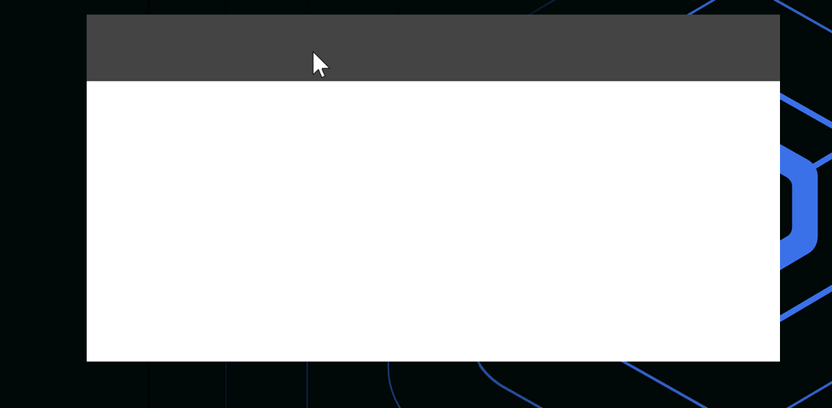

## Create transparent windows

To create a transparent window, pass two parameters to the `Window()` function: `transparent=true` and `undecorated=true`. The window must be undecorated because it is impossible to decorate a transparent window.

The following code sample demonstrates how to combine composables to create a transparent window with rounded corners:

import androidx.compose.foundation.layout.fillMaxSize import androidx.compose.foundation.layout.padding import androidx.compose.foundation.shape.RoundedCornerShape import androidx.compose.material.Surface import androidx.compose.runtime.mutableStateOf import androidx.compose.runtime.remember import androidx.compose.ui.Modifier import androidx.compose.ui.draw.shadow import androidx.compose.ui.graphics.Color import androidx.compose.ui.unit.dp import androidx.compose.ui.window.Window import androidx.compose.ui.window.application import androidx.compose.material.Text import androidx.compose.runtime.* fun main() = application { var isOpen by remember { mutableStateOf(true) } if (isOpen) { Window( onCloseRequest = { isOpen = false }, title = "Transparent Window Example", transparent = true, // Transparent window must be undecorated undecorated = true, ) { Surface( modifier = Modifier.fillMaxSize().padding(5.dp).shadow(3.dp, RoundedCornerShape(20.dp)), color = Color.Transparent, // Window with rounded corners shape = RoundedCornerShape(20.dp) ) { Text("Hello World!", color = Color.White) } } } }

## Use Swing components

Compose Multiplatform for desktop uses Swing under the hood, so you can create a window using Swing directly:

import androidx.compose.ui.awt.ComposeWindow import java.awt.Dimension import javax.swing.JFrame import javax.swing.SwingUtilities fun main() = SwingUtilities.invokeLater { ComposeWindow().apply { size = Dimension(300, 300) defaultCloseOperation = JFrame.DISPOSE_ON_CLOSE setContent { // Content of the window } isVisible = true } }

You can also use the scope of a `Window()` composable. In the following code sample, `window` is a `ComposeWindow` created inside `Window()`:

import androidx.compose.runtime.LaunchedEffect import androidx.compose.ui.window.singleWindowApplication import java.awt.datatransfer.DataFlavor import java.awt.dnd.DnDConstants import java.awt.dnd.DropTarget import java.awt.dnd.DropTargetAdapter import java.awt.dnd.DropTargetDropEvent fun main() = singleWindowApplication { LaunchedEffect(Unit) { window.dropTarget = DropTarget().apply { addDropTargetListener(object : DropTargetAdapter() { override fun drop(event: DropTargetDropEvent) { event.acceptDrop(DnDConstants.ACTION_COPY) val fileName = event.transferable.getTransferData(DataFlavor.javaFileListFlavor) println(fileName) } }) } } }

If you need to use a dialog implemented in Swing, you can wrap it into a composable function:

import androidx.compose.runtime.Composable import androidx.compose.runtime.getValue import androidx.compose.runtime.mutableStateOf import androidx.compose.runtime.remember import androidx.compose.runtime.setValue import androidx.compose.ui.window.AwtWindow import androidx.compose.ui.window.application import java.awt.FileDialog import java.awt.Frame fun main() = application { var isOpen by remember { mutableStateOf(true) } if (isOpen) { FileDialog( onCloseRequest = { isOpen = false println("Result $it") } ) } } @Composable private fun FileDialog( parent: Frame? = null, onCloseRequest: (result: String?) -> Unit ) = AwtWindow( create = { object : FileDialog(parent, "Choose a file", LOAD) { override fun setVisible(value: Boolean) { super.setVisible(value) if (value) { onCloseRequest(file) } } } }, dispose = FileDialog::dispose )

## Window and dialog API v2

Starting with Compose Multiplatform 1.12.0, the redesigned `WindowState` and `DialogState` classes are available in the `androidx.compose.ui.window.v2` subpackage.

The v2 window and dialog API separates requesting a state from observing the state actually applied by the window manager. It also unlocks scenarios that weren't possible before, such as sizing a window to its content's preferred size while still letting the content expand (via modifiers like `fillMaxSize()`) when the window is larger. See Specify size for details.

The v2 API is available alongside the existing API described in the rest of this page, so you can migrate individual windows at your own pace.

### Specify and observe state

The v2 API explicitly separates specifying the desired state from observing the actual state.

To specify the initial state of a window, pass providers to `rememberWindowState()`:

import androidx.compose.material.Text import androidx.compose.ui.ExperimentalComposeUiApi import androidx.compose.ui.unit.DpSize import androidx.compose.ui.unit.dp import androidx.compose.ui.unit.sp import androidx.compose.ui.window.application import androidx.compose.ui.window.v2.Window import androidx.compose.ui.window.v2.WindowBoundsProvider import androidx.compose.ui.window.v2.WindowPositionProvider import androidx.compose.ui.window.v2.WindowSizeProvider import androidx.compose.ui.window.v2.rememberWindowState @OptIn(ExperimentalComposeUiApi::class) fun main() = application { val windowState = rememberWindowState( initialBoundsProvider = WindowBoundsProvider( positionProvider = WindowPositionProvider.CenteredOnScreen, sizeProvider = WindowSizeProvider.Fixed(DpSize(400.dp, 200.dp)) ) ) Window( onCloseRequest = ::exitApplication, state = windowState, ) { Text("Hello, World!", fontSize = 48.sp) } }

To request a state change after the window has been created, call the corresponding method on `WindowState`. You can specify the exact size and position directly:

```
windowState.requestScreen { defaultScreen }
windowState.requestSize(DpSize(1024.dp, 768.dp))
windowState.requestPosition(DpOffset(100.dp, 100.dp))
```

For relative positioning or to calculate dimensions dynamically, use providers:

```
windowState.requestBounds(
    WindowBoundsProvider(
        positionProvider = WindowPositionProvider.CenteredOnScreen,
        sizeProvider = WindowSizeProvider.Fixed(DpSize(1024.dp, 768.dp))
    )
)
```

Applying a request is asynchronous. The windowing system may adjust the requested state, and the actual state may change later, for example, when you move or resize the window. Observe the actual state of a window via `WindowState.screenId` and `WindowState.bounds`:

```
if (windowState.isInitialized) {
    Text("Current screen: ${windowState.screenId}")
    Text("Current bounds: ${windowState.bounds}")
}
```

The same asynchronous model is available for dialogs via `DialogState` and `rememberDialogState()`.

### Choose a screen

You can request the screen on which a window should appear either by passing an `initialScreenProvider` to `rememberWindowState()` or by calling `WindowState.requestScreen()` later. The screen the window is actually placed on is observable via `WindowState.screenId`.

For example, you can request a window to be placed on a screen whose available width is at least `1024.dp`, falling back to the default screen:

```
windowState.requestScreen {
    screens.firstOrNull { it.availableBounds.width >= 1024.dp }
        ?: defaultScreen
}
```

### Specify position

To change the window position, either pass an `initialBoundsProvider` to `rememberWindowState()` or call `WindowState.requestBounds()` later. The actual bounds of the window are observable via `WindowState.bounds`.

The v2 API uses `WindowPositionProvider` to get information about the screen and parent window geometry.

For standard placements, you can use the built-in properties:

- `Default` applies the operating system's standard cascading behavior.
- `Current` maintains the current position of the window.
- `CenteredOnScreen` centers the window within the screen.
- `CenteredInParentWindow` centers the window within its parent window.

For more control, use position provider functions:

- `Absolute()` places the window starting corner at specified `x` and `y` coordinates.
- `AlignedToScreen()` aligns the window relative to the screen and includes an optional offset parameter.

  ```
  WindowPositionProvider.AlignedToScreen(
      alignment = Alignment.Center,
      offset = DpOffset(x = 16.dp, y = 16.dp)
  )
  ```

- `AlignedToParentWindow()` anchors the window to the parent window, typically useful for dialogs.

  ```
  WindowPositionProvider.AlignedToParentWindow(
      // Anchors to the starting corner of the parent window
      anchor = Alignment.TopStart,
      // Applies alignment relative to the anchor point
      alignment = Alignment.Center
  )
  ```

### Specify size

Sizing is also part of the window bounds, so it is configured through the same `initialBoundsProvider`/`WindowState.requestBounds()` mechanism.

The v2 API uses `WindowSizeProvider` to get information about the screen and parent window sizes, as well as to query the content of the window for its intrinsic sizes.

Common built-in options include `Fixed()` for a specific window size and `Default` for the standard 800×600 dp size.

For custom sizing, a `WindowSizeProvider()` lambda has access to screen metrics and, for dialogs, parent window metrics:

```
WindowSizeProvider {
    val height = parentWindowMetrics!!.bounds.height
    DpSize(300.dp, height)
}
```

The v2 API enables one commonly requested scenario: size a window to its content's preferred size while still letting the content fill the window when the user makes it larger. `WindowSizeProvider.Unconstrained` calculates the content's size, adds the window insets, and caps the result at the available screen size. Since sizing is decoupled from layout, content that uses `fillMaxSize()` still expands to fill the window if the user resizes it.

```
WindowBoundsProvider(
    positionProvider = WindowPositionProvider.CenteredOnScreen,
    sizeProvider = WindowSizeProvider.Unconstrained
)
```

The v2 versions of the `Window()` and `DialogWindow()` composables accept `minSize` and `maxSize` parameters. Where the underlying window manager supports it, the user will not be able to resize the window past these bounds:

```
DialogWindow(
    onCloseRequest = { showDialog = false },
    state = dialogState,
    minSize = DpSize(250.dp, 250.dp),
    maxSize = DpSize(500.dp, 500.dp)
) {
    // ...
}
```

## What's next

Explore the tutorials about other desktop components.

25 August 2026